[figure not shown]

Rear Wiring Harness and Trunk Lid Cord

74.Rear Wiring Harness and Trunk Lid Cord

A: LOCATION

Connector Connecting to

No. Pole Color Area No. Description

AB31 2 B B-2 Curtain airbag module LH

AB32 4 Y C-1 Curtain airbag sensor LH

AB33 2 B A-4 Curtain airbag module RH

AB34 4 Y B-4 Curtain airbag sensor RH

AB41 2 Y B-2 Satellite safing sensor

R11 2 B C-3 Rear differential oil temperature sensor

R14 4 B-3 J/C

R16 3 B-4 Rear door switch RH

R17 1 B B-4 Amplifier bracket ground

R19 2 B-4 High-mounted stop light

R20 2 B B-4 Trunk room light

R22 3 C-2 Rear door switch LH

R24 12 B-4 R60 Trunk lid cord

R26 6 B-5 Rear combination light RH

R28 6 C-3 Rear combination light LH

R29 3 B C-3 Rear vehicle height sensor

R58

6 GR B-2 Fuel pump assembly (engine type EJ)

4 B-2 Fuel pump assembly (engine type FA)

R59 2 B-2 Fuel sub level sensor

R60 12 B-5 R24 Rear wiring harness RH

R65 1 B B-2 Rear defogger (–)

R72 2 GR B-3 Rear ABS wheel speed sensor RH

R73 2 GR C-2 Rear ABS wheel speed sensor LH

R76 2 C-4 License plate light LH

R77 2 B-4 License plate light RH

R80 8 B-3 Keyless entry CM (without push button start)

R97 1 B-2 AN8 Antenna cord

R117 4 B-3 Woofer

R122

6 B-4 Fuel pump CM (engine type FA)

10 GR B-4 Fuel pump CM (engine type EJ)

R174 1 B A-4 Rear defogger (+)

R186 3 C-4 Trunk lid lock actuator & switch

R211 12 C-2 TPMS CM

R221 12 B-3 TPMS & keyless entry CM

R294 2 BR B-4 Trunk opener button

R296 5 B-3 Receiver (with push button start)

R297 3 B-3 Keyless access interior antenna (rear)

R298 3 B-3 Keyless access interior antenna (center)

R299 6 C-4 Keyless access exterior antenna (rear)

R316 10 B-3

Audio amplifier

R317 12 B-3

R330 4 B-5 R356 Trunk lid cord

R356 4 B-5 R330 Rear wiring harness RH

R357 4 C-4 Rearview camera

R386 24 B-3 Audio amplifier

R400 8 B-3 ELCM

: White or natural color

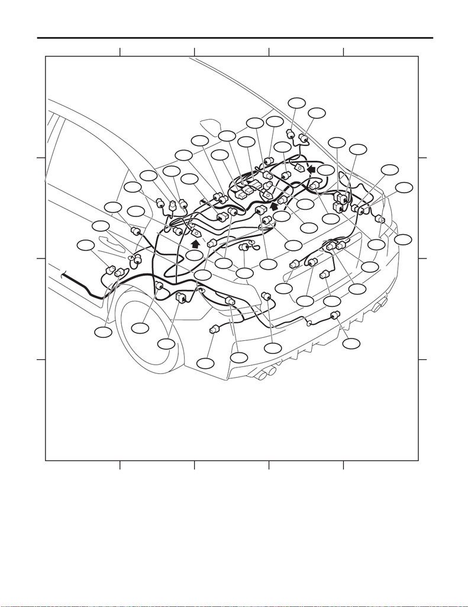

12345

12345

A

B

C

D

A

B

C

D

R65

AB31

AB41

R59

R22

R73

R211

R298

R11

R28

R76

R186

R299

R357

R400

R117

R72

R19

R29

R58

AB32

R297

R297

R317

R316

R386

R14

R16

AB33

R174

AB34

R17

R20

R122

R330

R26

R77

R24

R60

R356

R294

R97

GB10

GB-11

GB-12

1

2

1:STANDARD MODEL WITHOUT PUSH BUTTON START WITHOUT TPMS:R80

2:PREMIUM MODEL WITHOUT PUSH BUTTON START:R221

3:PREMIUM MODEL

4:STANDARD MODEL

STANDARD MODEL WITHOUT PUSH BUTTON START WITH TPMS:R221

STANDARD MODEL WITH PUSH BUTTON START:R296

PREMIUM MODEL WITH PUSH BUTTON START:R296

*3

*4